# PSpecteR Manual v.2019.10.07

## 4. Protein Tree Page

### Page Description

This page allows you to visualize how every identified peptide sequence maps to its database protein.

### Set Filters

1. **Protein Tree Range:** Set the range values of the Match graphic. See “2.2 Spectrum Ranges.”

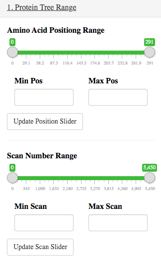

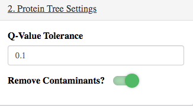

3. **Take Image Snapshot:** Take a high-res snapshot of the images. See “Exportations” for more details.
4. **Export Data:** Export the data in the Protein Tree table (only table on the page). See “Exportations” for more details.

### View Graphics

5. **Match:** Click a protein on the table to see how every identified peptide sequence maps to that protein. Hover-over information reveals the scan number and sequence.

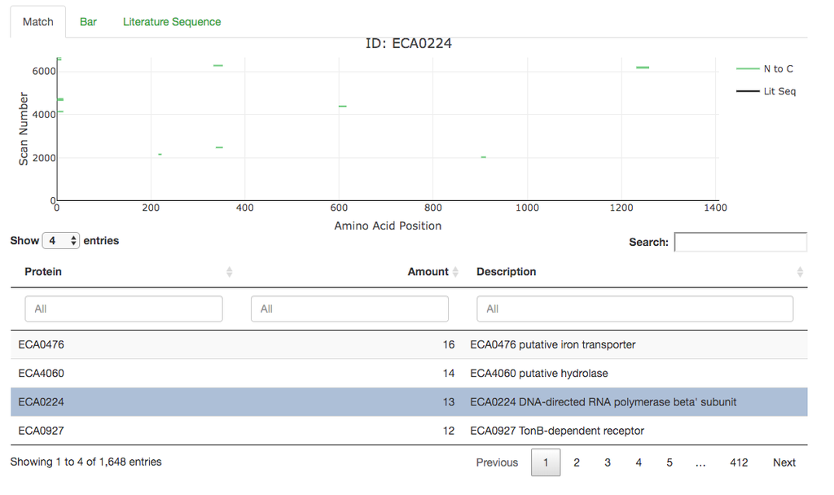

6. **Bar:** See the number of times each amino acid in the literature sequence was identified.

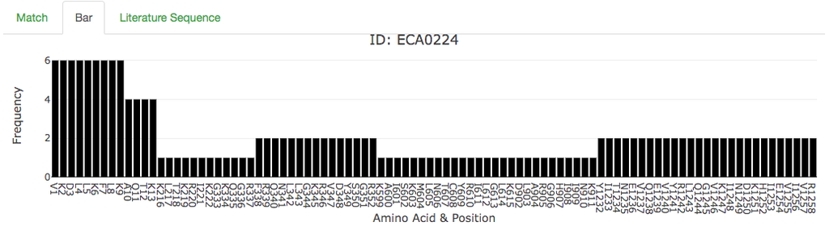

7. **Literature Sequence:** View the full literature sequence with regions identified by peptides in green.

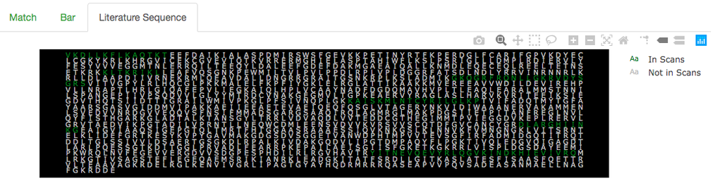

## DB Search: MSGF+

### Generate Configuration File

1. **Precursor Tolerance:** Set symmetric tolerance values. For example 15ppm will be set 0.000015 Da to the left and the right.

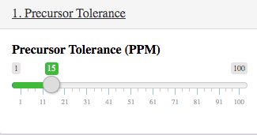

2. **Modifications:** Set the max number of modifications per peptide. If this value is large, the search will be slow. Then set modifications that are static (applied to every possible peptide) and/or dynamic (applied to multiple combinations of peptides).

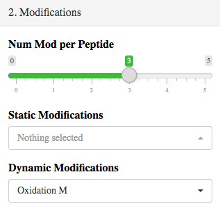

3. **MS Acquisition:** Select the fragmentation method, instrument, enzyme, and number of tolerable termini (which indicates how tryptic an enzyme was in a bottom-up technique). Remember that bottom-up involves the use of an enzyme to break a peptide before mass spec acquisition. Next, set the isotopic error range in PPM, which takes into account the error introduced by choosing a non-monoisotopic peak for fragmentation. It’s useful for accurate precursor ion masses.

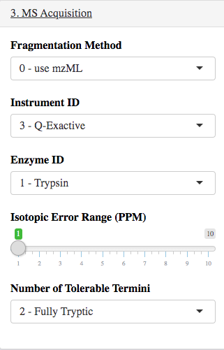

4. **Other MSGF Settings:** Set whether the target decoy database will be searched (improves algorithm results), the number of threads, the min/max peptide length, the min/max charge, the number of permissable matches per spectrum, the minimum number of acceptable peaks per spectrum, and whether to output additional features.

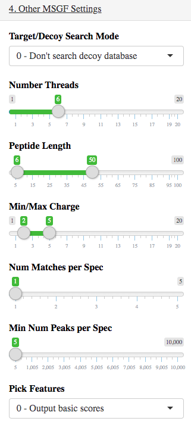

5. **Additional .mzML Files:** Additional mzML files can be added or removed. Only the first mzML & mzid file will be visualized in the app.

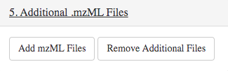

6. **Run MSGF+:** Click the “Run MSGF+” button to start the peptide database search tool. A green checkmark will let you know the algorithm is running, and the resulting data will be written in the “Output” tab (Apple products) or in the command.exe window (Microsoft products). The algorithm can be cancelled at anytime. The outputted .mzid file is loaded into PSpecteR, and exported to its own folder in downloads along with the configuration text file.

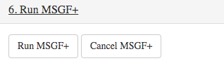

### MSGF+ Inputs/Outputs

7. **Input:** The input page will let you know everything that will be written in the text file as well as the names of all inputted files. Watch it update in real time as you adjust algorithmic parameters!

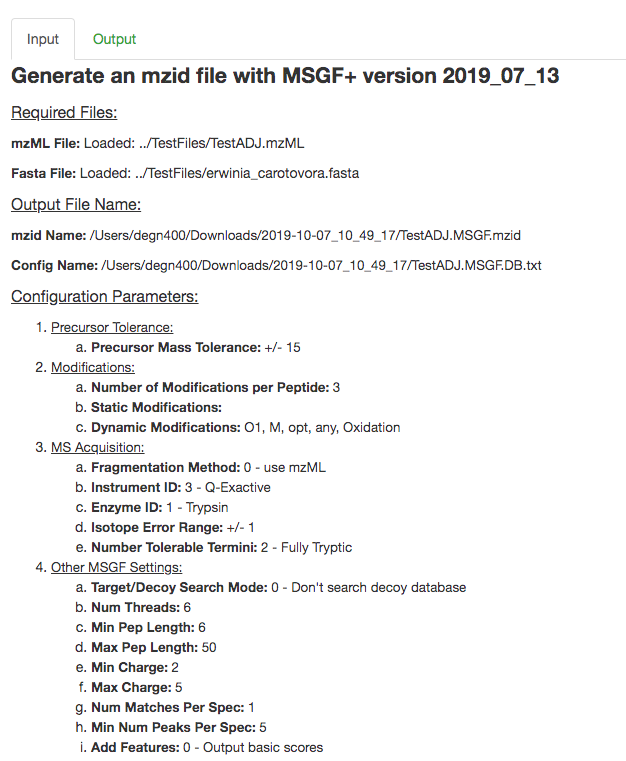

8. **Output:** Shows the output of the algorithm as it runs. Here is an example of a complete run:

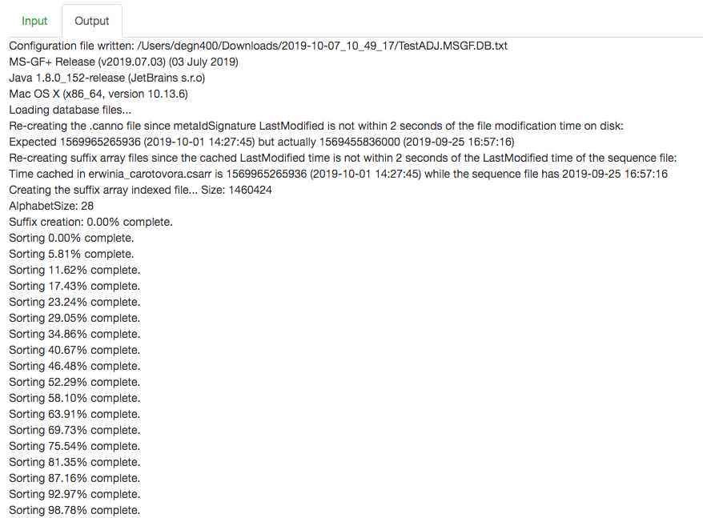

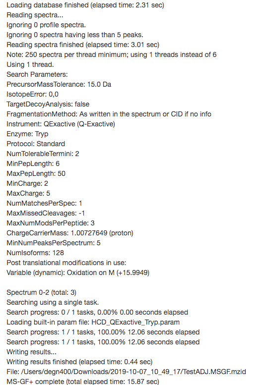

## DB Search: MSPathFinder

**COMING SOON**

## A Feature Plot

### Page Description

Visualize the metadata from the “Scan” table in “2. Scan & Seq.”

### Functions & Graphs

1. **Subset Data:** Since the MS data can be quite large, choose a random subset size if desired. 6 means that 1/6 of the data will be randomly selected and visualized.

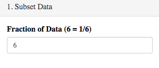

2. **Select Variables:** Select the Feature Plot’s X, Y, and label variables. More visualization options are enabled when an ID file is included.

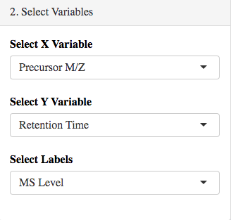

3. **Take Image Snapshot:** Take a high-res snapshot of the data. See “Exportations” for more info.
4. **Feature Plot:** Visualize the metadata across all scans.

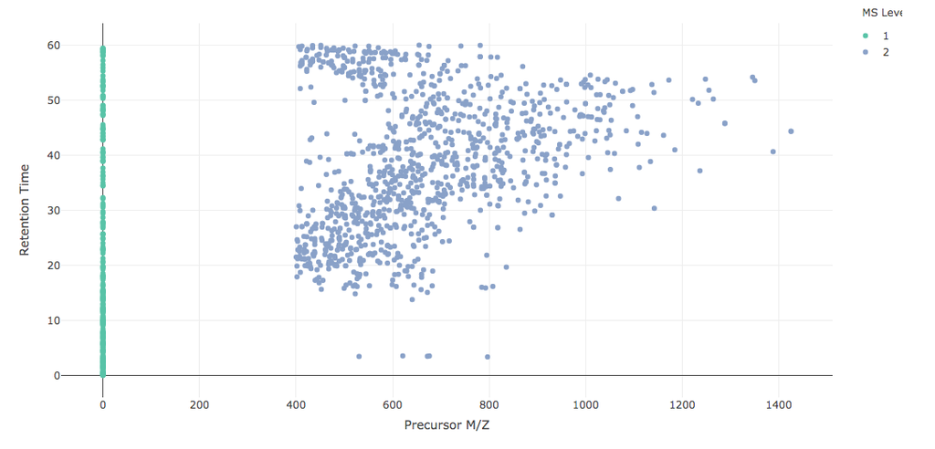

## B MS1 Feature Plot

### Page Description

A special feature plot which visualizes metadata from only MS1 scans.

### Functions & Graphs

1. **MS2 Annotation:** Annotate each point (which represent an MS1 scan) an associated MS2 scan if there is any.

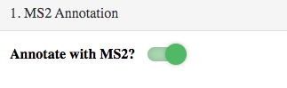

2. **Set X Axis:** Change the X-axis from Retention Time to Scan Number.

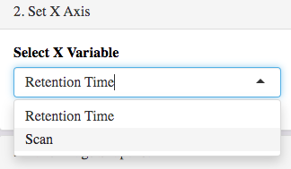

3. **Take Image Snapshot:** Take a high-res snapshot of the MS1 Feature Plot. See “Exportations” for more details.
4. **MS1 Feature Plot:** Visualize metadata from MS1 scans.

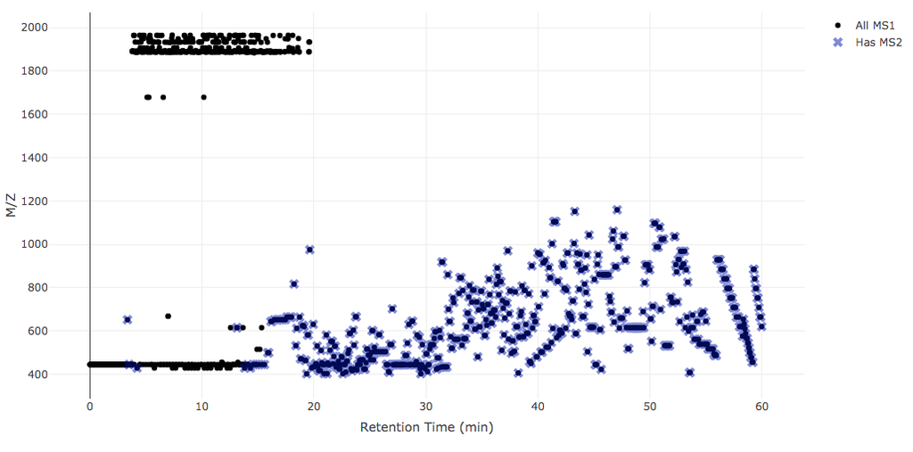

## C Unimod Glossary

### Page Description

View and append the database of post-translatinal modifications PSpecteR uses in its Vis PTM page.

### Functions

1. **Select Columns:** Select columns from the Unimod Glossary to view.

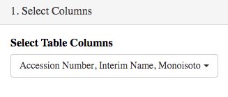

2. **Append Table:** Add post-translation modifications with a pop-up window or upload as a CSV (CSV upload currently not functional).

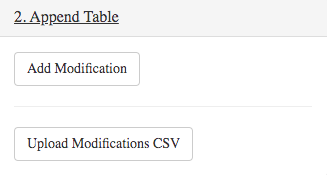

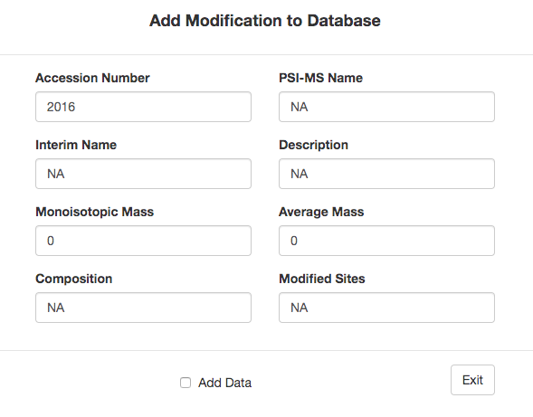

3. **Unimod Glossary:** The table can be searched and sorted.

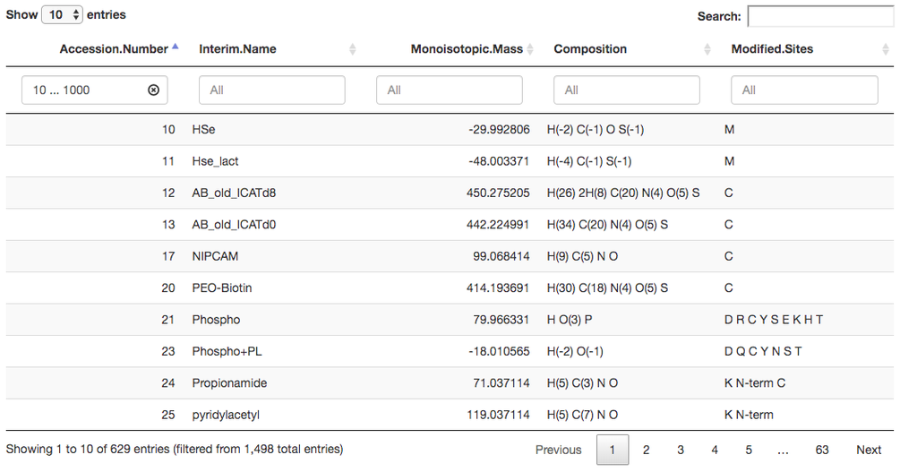

## Exportations

### Exporting Data

Click any “Export Data” button.

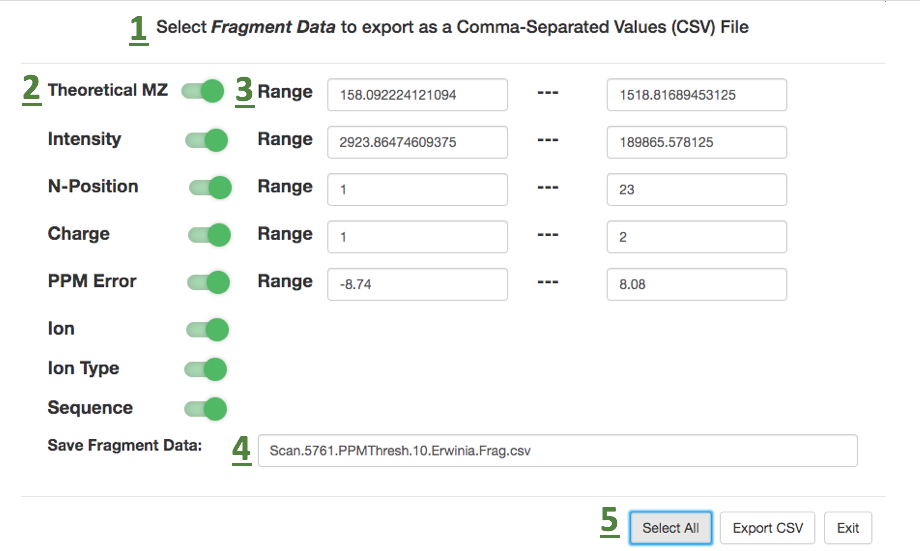

### Exporting Images

Click the “Export Snapshot Images” button. It does not matter which page you are currently in.

[figure not shown]

1. Select a table row to visualize the image.
2. Delete all the images or delete that row’s image, if desired.
3. Export data as a PNG…
4. ..or a JPG.
5. PDF export may not work (still testing).
6. Exit if necessary.

All exported images are written to their own timestamped folder in the Downloads folder.

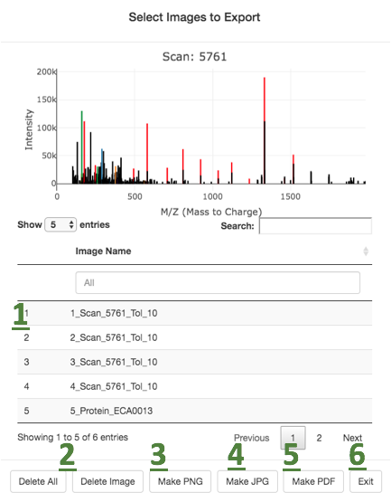